# Notebook: replicating article figures for “Averting the steel carbon lock-in through strategic green investments”

Clara Bachorz

In this notebook, we replicate the figures and analyses shown in the paper.

## Setup

Make sure to run all the cells in this section.

### Load source R files for analysis and plotting

### Create figs folder if it does not exist

### Define the scenarios and key parameters

```r
# define scenarios to compare.
# each scenario is a list with:
# 1) the scenario name
# 2) and 3): REMIND scenario output: the gdx file (unprocessed) and the mif file (processed gdx file)
# 4) the average levelized cost of steel (calculated with lco_analysis.R using the gdx file)

scenario_CP <- list(
  name = "Current policies",
  mif_file = "inputdata/mif/REMIND_generic_TransitionwLockIn-NPi.mif",
  gdx = "inputdata/gdx/TransitionwLockIn-NPi.gdx",
  lcop_file = "./inputdata/other/lcop_avg_npi.csv"
)
scenario_TWLI <- list(
  name = "Transition with lock-in",
  mif_file = "inputdata/mif/REMIND_generic_TransitionwLockIn-PkBudg820.mif",
  gdx = "inputdata/gdx/TransitionwLockIn-PkBudg820.gdx",
  lcop_file = "./inputdata/other/lcop_avg_transition_with_lock-in.csv"
)
scenario_FT <- list(
  name = "Fast transition",
  mif_file = "inputdata/mif/REMIND_generic_FastTransition-PkBudg820.mif",
  gdx = "inputdata/gdx/FastTransition-PkBudg820.gdx",
  lcop_file = "./inputdata/other/lcop_avg_fast_transition.csv"
)
scenario_TWLI_1p5LO <- list(
  name = "Transition with lock-in 650",
  mif_file = "inputdata/mif/REMIND_generic_TransitionwLockIn-PkBudg650.mif",
  gdx = "inputdata/gdx/TransitionwLockIn-PkBudg650.gdx",
  lcop_file = "./inputdata/other/lcop_avg_transition_with_lock-in_650.csv"
)

#other scenario definitions for sensitivity analysis (supplementary only)
scenario_FT_1p5LO <- list(
  name = "FT 650",
  mif_file = "inputdata/mif/REMIND_generic_FastTransition-PkBudg650.mif"
)

scenario_TWLI_2C <- list(
  name = "Transition with lock-in 2C",
  mif_file = "inputdata/mif/REMIND_generic_TransitionwLockIn-PkBudg1000.mif"
)

scenario_FT_2C <- list(
  name = "FT 2C",
  mif_file = "inputdata/mif/REMIND_generic_FastTransition-PkBudg1000.mif"
)

scenario_TWLI_lowBio_highCCS <- list(
  name = "Transition with lock-in low bio high CCS",
  mif_file = "inputdata/mif/REMIND_generic_TransitionwLockIn_lowBio_highCCSinjecrate-PkBudg820.mif"
)

scenario_TWLI_lowBio <- list(
  name = "Transition with lock-in low bio",
  mif_file = "inputdata/mif/REMIND_generic_TransitionwLockIn_lowBio-PkBudg820.mif"
)

scenario_TWLI_highCCS <- list(
  name = "Transition with lock-in high CCS",
  mif_file = "inputdata/mif/REMIND_generic_TransitionwLockIn_highCCSinjecrate-PkBudg820.mif"
)

scenarios <- list(scenario_CP, scenario_TWLI, scenario_FT)
scenarios_for_lcop <- list(scenario_CP, scenario_TWLI, scenario_FT, scenario_TWLI_1p5LO)

#create list of scenarios with mif data
mif_list <- lapply(scenarios, function(scen) {
  mif <- read.quitte(scen$mif_file)
  mif$scenario <- scen$name
  mif
})

# for the abatement figures: select which regions to aggregate.
# Default: other asia + latin america,
# and global north countries.
region_to_aggr <- list(
  "OASLAM" = c("OAS", "LAM"),
  "EUR+NEU+USA+JPN+REF+CAZ" = c("EUR", "USA", "CAZ", "NEU", "REF", "JPN")
)

### key input parameters: what period to consider when calculating cumulative emissions and costs
### and what discount rate to use.
start_date <- 2025
end_date <- 2070
discount_rate <- 0.05
```

## Preparatory calculations: GEM GIST data and levelized cost of steel from REMIND scenario data

These output of these calculations are already in the repository, under inputdata/gem and inputdata/other. If you wish to reproduce the calculation, run the cells below. Otherwise, feel free to skip ahead to the next section to plot the figures.

### Run Python script to calculate historical and future BOF capacity additions from GEM data

This is used to generate the files in the folder ./inputdata/gem, which are used to plot Figures 1 and 2. This cell does not need to be ran, unless changes have been made to eg. relining cycle time assumptions (defined in main()).

```r
# install python dependencies if not done already
if (!file.exists("analysis/python/.venv")) {
  message("Setting up Python environment...")
  system("poetry -C analysis/python install --no-root")
}

# run python script to calculate BOF capacity from GEM data
# the input data can be found in inputdata/python_source, and is the March 2025 version.
system("poetry -C analysis/python run python analysis/python/run_bof_capacity_calculation.py")
```

### Calculate average levelized cost of steel (LCOP) from REMIND scenarios

This cell does not need to be ran unless the gdx/mif files for the scenarios have been changed. Here, we calculate the levelized cost of steel. The result can be displayed in two ways: 1. Show the average LCO for each steel production route, for a given year and region. “Average” means the average LCO over the plant lifetime. Eg. the average LCO for a BF-BOF plant that is built in 2030 in India = the average LCO over 2030-2065 (assuming a 35 year lifetime). 2. Show the weighted LCO for all steel produced in a given year and region. “Weighted” means that the individual LCOs for each production pathway (BF-BOF, H2-DRI-EAF …) are weighted by their yearly production to reach a weighted average LCO for each year and region. This is the metric that is used to calculate average abatement costs (see abatement_costs.R).

```r
# calculates the levelized cost of steel for all scenarios.
# this is then used for the abatement cost calculation
# (saved under the filenames lcop_avg_*)

for (scen in scenarios_for_lcop){
  # calculate and plot average LCO
  p_avg <- plot_average_lcop(
    gdx = scen$gdx,
    fs = 10,
    save_plot = TRUE,
    scenario_name = scen$name
  )

  # calculate and plot weighted LCO
  # (and save the data, which is used for the abatement cost calculation)
  p_weighted <- plot_weighted_lcop(
    gdx = scen$gdx,
    fs = 10,
    save_data = TRUE,
    save_plot = TRUE,
    scenario_name = scen$name
  )
  ## uncomment to print the plots while running the script
  print(p_avg)
  # print(p_weighted)
}
```

## Plot Figures 1 and 2

Plot the processed GEM data to get Figure 1 (primary steel production + capacity additions) and Figure 2 (estimating the steel fossil lock-in).

```
## Ignoring unknown labels:
## • colour : "Region"
## Ignoring unknown labels:
## • colour : "Region"
```

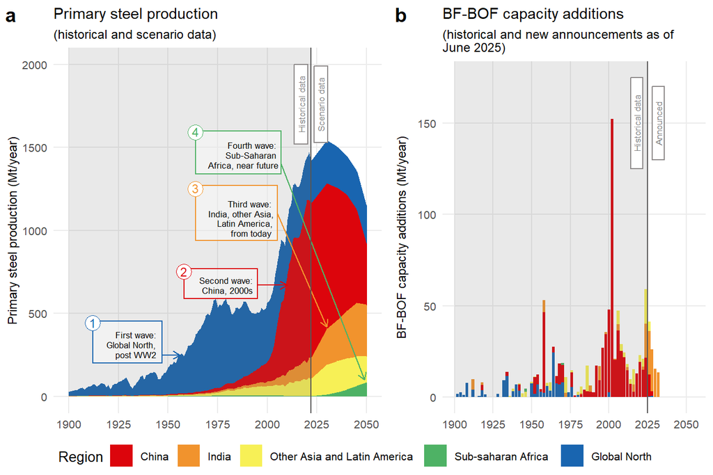

```r
# plot regional production data (historical and scenario data) and
# capacity additions (historical and recent announcements)
plot_combine_production_and_cap_additions(save_plot = TRUE)
```

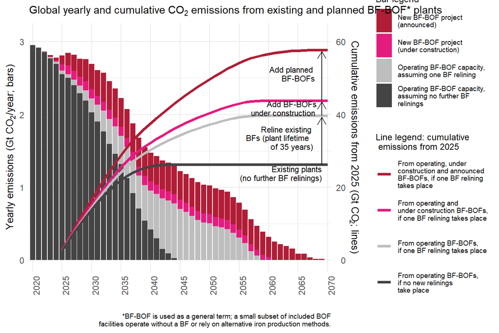

```r
# # plot steel-lock in figure, based on the assumption of 1 relining (15+20 year lifetime)
plot_emissions_1relining(save_plot = TRUE)
```

## Plot Figure 3

The chunk below includes different steel production plots (by route) from REMIND scenario results.

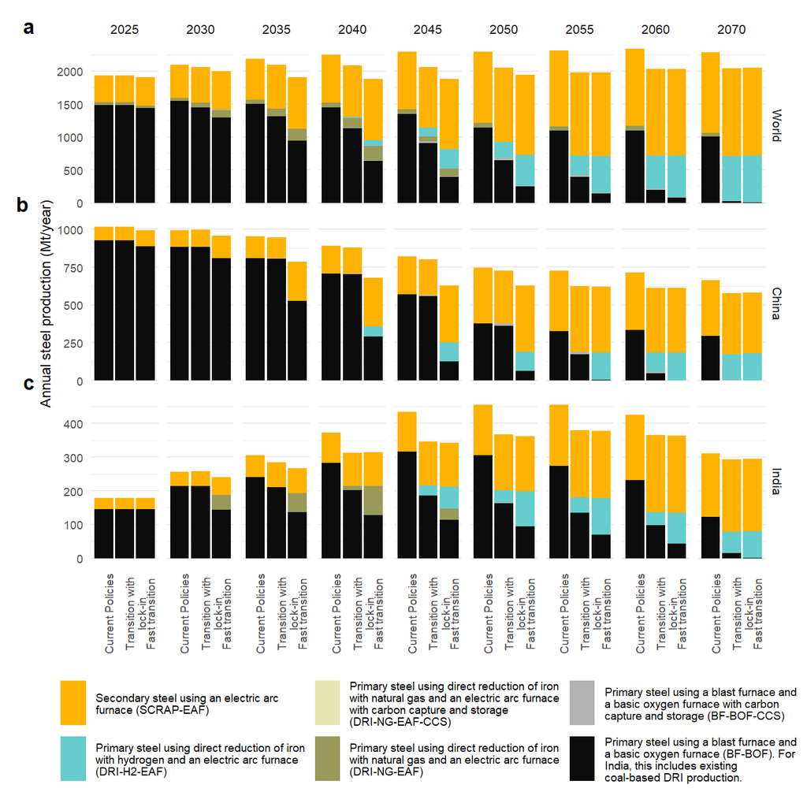

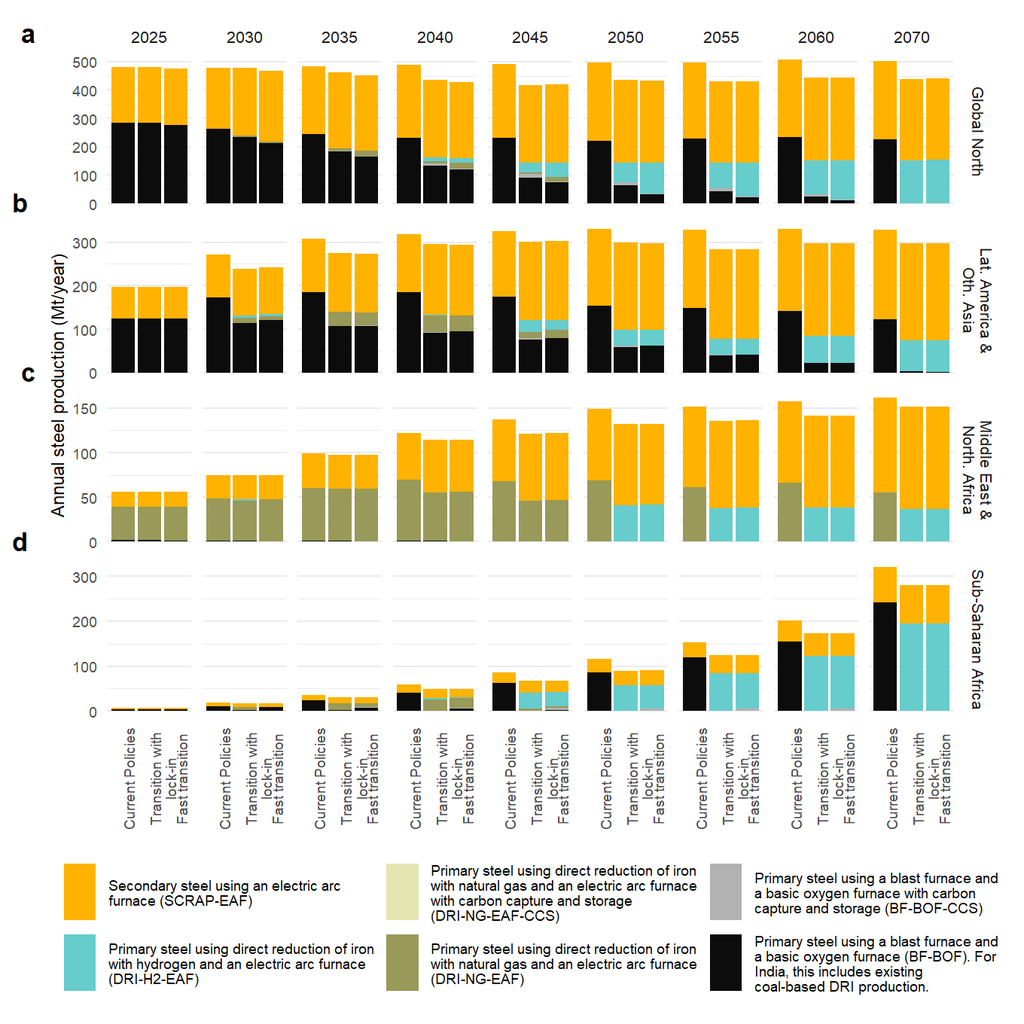

```r
# Plot Figure 3 and Figure ED2
plot_stacked_production_plots(mif_list)
```

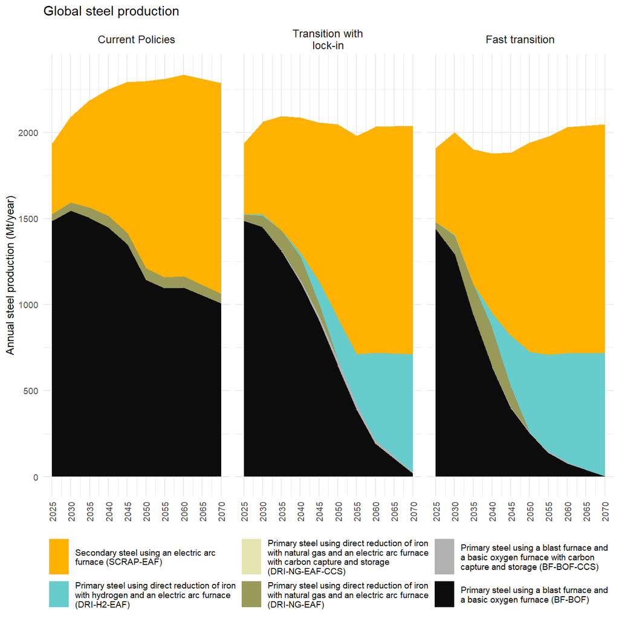

```r
# Plot Figure ED1 (partial reproduction without annotations, these were added manually)
plot_area_production_plots(mif_list)
```

## Plot Figure 4

This figure is composed of three different elements: 1. Average abatement costs for the emission reductions achieved between each of the three scenarios, combined with 2. an emission cascade plot (Figure 4a), as well as 3. a steel system cost vs cost of other mitigation option plot (Figure 4b).

### 1. Get average abatement costs

Plot the average abatement costs calculated for different scenario pairs. The average abatement cost is a single metric, which yield the average CO2 price required over a certain time period (here: 2025-2070) to reach cost parity between two scenarios. This is **not** a marginal abatement cost. The average abatement costs calculated are later added to Figure 4 (emission cascade plot)

```r
run_and_save_abatement_cost_plot <- function(scenario1, scenario2, region_to_aggr, start_date, end_date, discount_rate, save_plot = FALSE, filename = NULL) {
  ## "scen1" should be the lower ambition scenario
  results <- run_abatement_analysis(
    scen1 = scenario1,
    scen2 = scenario2,
    region_to_aggr = region_to_aggr,
    start_date = start_date,
    end_date = end_date,
    discount_rate = discount_rate
  )

  #save
  if (save_plot) {
    ggsave(paste0(filename, ".png"), plot = results$plot, width = 180, height = 90, unit = "mm")
    ggsave(paste0(filename, ".svg"), plot = results$plot, width = 180, height = 90, unit = "mm")
    }
  return(results$fscp_df_grouped %>% mutate(scenario1 = scenario1$name, scenario2 = scenario2$name))
}

#### Abatement costs: NPi to Fast Transition
#### saves the plot and returns the df used
df_plot <- run_and_save_abatement_cost_plot(scenario_CP, scenario_FT, region_to_aggr, start_date, end_date, discount_rate)
#### Abatement costs: NPi to Lockin
#### this is also Figure ED3
#### saves the plot and returns the df used
df_plot1 <- run_and_save_abatement_cost_plot(scenario_CP, scenario_TWLI, region_to_aggr, start_date, end_date, discount_rate, save_plot = TRUE, filename = "./figs/FigureED3")
#### Abatement costs: Lockin to fast transition
#### saves the plot and returns the df used
df_plot2 <- run_and_save_abatement_cost_plot(scenario_TWLI, scenario_FT, region_to_aggr, start_date, end_date, discount_rate)

##### combine the average abatement cost dfs
##### (scen 0 -> scen 1 and scen1 -> scen 2 are the relevant ones here)
#### used later for the cascade plot
#### we add the fscp over the categories (energy and non-energy)
df_aac_combined <- rbind(df_plot1, df_plot2) %>%
  select(fscp, region, category, scenario1, scenario2) %>%
  group_by(region, scenario1, scenario2) %>%
  summarise(fscp = sum(fscp)) %>%
  ungroup()
```

### Add 2. and 3. to plot Figure 4:

Plot Figure 4: combine the cumulated emission cascade plot with the scenario costs vs CO2 value plot. Add the average abatement cost information to the cascade (df_aac_combined).

We first plot Figure 4b., which shows the total additional cost of the *Fast Transition* scenario compared to *Transition with Lock-in* scenario (over a defined period and discount rate). This is compared to the value of the additional CO2 abated (calculated using CO2 price * emission reduction between the two scenarios).

Then, we combine this plot (`p_scenariocost_vs_co2value`) with the emission cascade using `combine_cascade_cumueum_and_co2value_plot`.

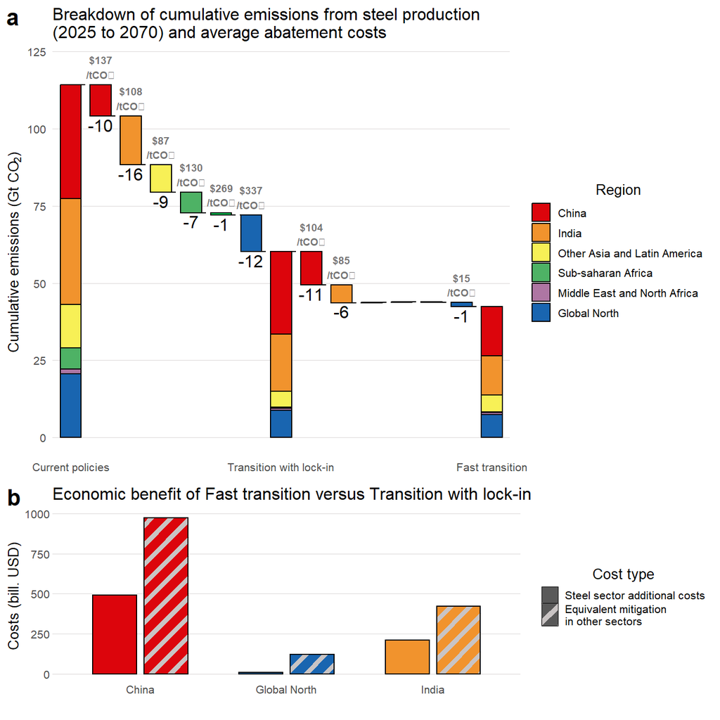

```r
# Make Fig 4b: scenario additional costs vs co2 value
df <- run_scenario_cost_andCO2value_comparison(scenario_TWLI, scenario_FT, region_to_aggr, start_date, end_date, discount_rate = discount_rate)
p_scenariocost_vs_co2value <- df$plot

## Combine all elements in Figure 4:
combine_cascade_cumueum_and_co2value_plot(mif_list, df_aac_combined, p_scenariocost_vs_co2value, show_aac_annotations = TRUE)
```

```r
## Additional plots: yearly emission cascades for specific years
# plot_cascade_yearlyem(mif_list, year_to_plot= 2050)
# plot_cascade_yearlyem(mif_list, year_to_plot= 2060)
# plot_cascade_yearlyem(mif_list, year_to_plot= 2070)
```

## Plot Figure 5: Investments required in India in the different scenarios

We also plot Figure ED4 in this code block: the remaining expenditure required from other fuels (fossil gas, biogas, fossil coal, biomass solids).

```r
## calculate total investment costs for all scenarios and regions
df.totalcosts <- combine_investment_costs(scenarios)
```

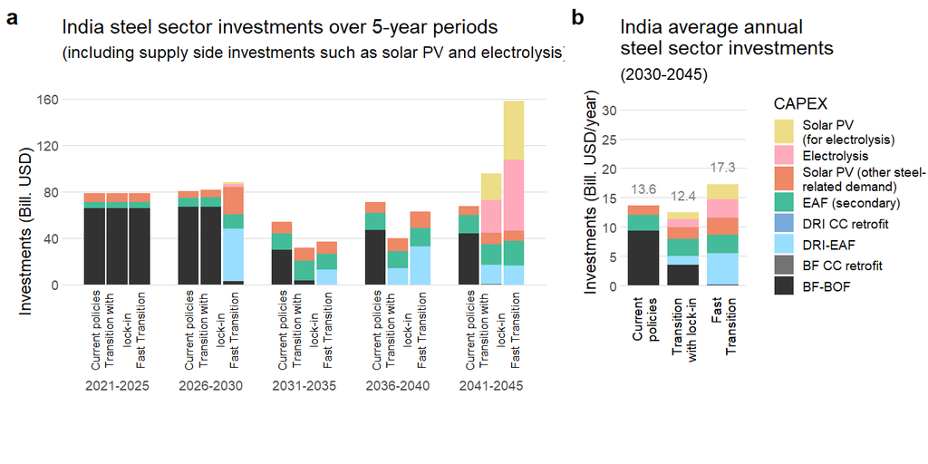

```r
# plot investment costs for India
# Figure 5
plot_invst_costs_v2(df.totalcosts, region_to_plot = "IND", save_plot = TRUE)
```

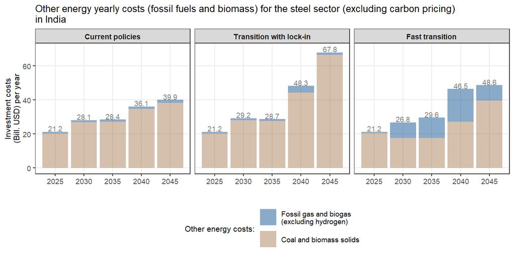

```r
# fossil costs only (last missing steel system cost component)
# Figure ED4
plot_invst_fossil(df.totalcosts, region_to_plot = "IND",save_plot = TRUE)
```

## Plot Supplementary Figures

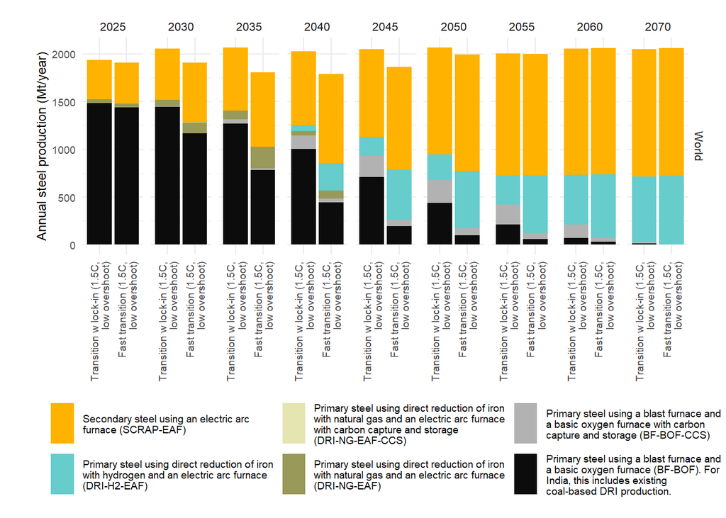

```r
source("./analysis/R/supp_and_ext_plots.R")


#create list of gdx files
gdx_list <- list()
gdx_list$gdx <- lapply(scenarios, function(scen) {
  scen$gdx
})
gdx_list$name <- lapply(scenarios, function(scen) {
  scen$name
})

#create list of scenarios with mif data
scens_1p5LO <- list(scenario_FT_1p5LO, scenario_TWLI_1p5LO)
mif_list_1p5LO <- lapply(scens_1p5LO, function(scen) {
  mif <- read.quitte(scen$mif_file)
  mif
})

plot_REMIND_steel_production(mif_list_1p5LO, fig_name = "FigureS1")
```

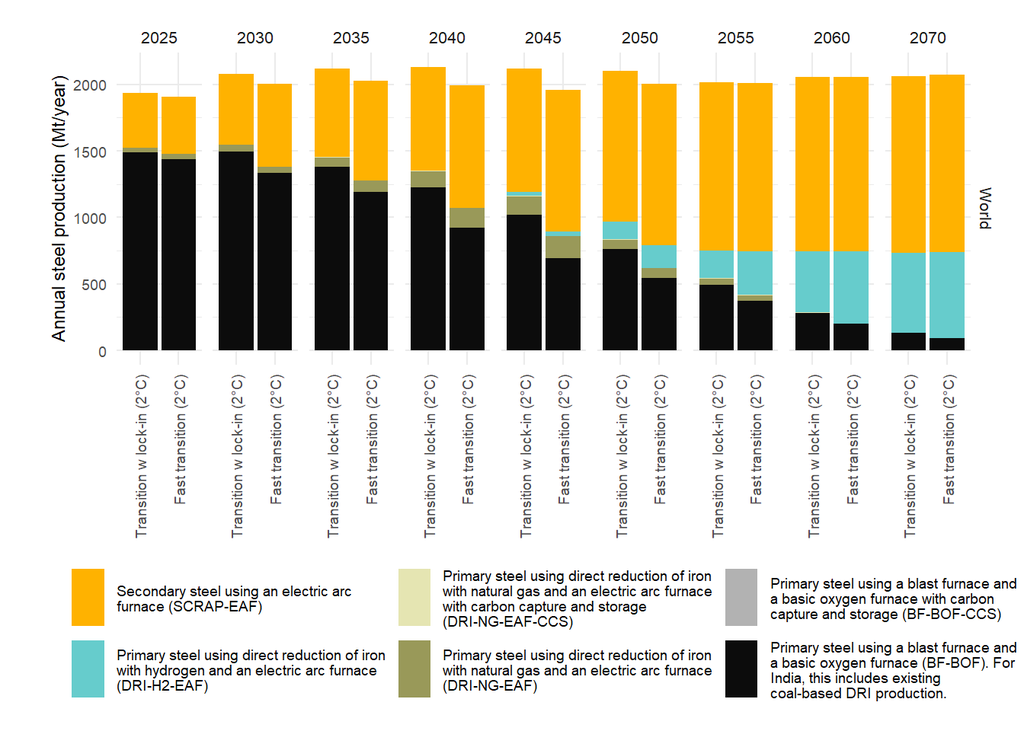

```r
scens_2C <- list(scenario_FT_2C, scenario_TWLI_2C)
mif_list_2C <- lapply(scens_2C, function(scen) {
  mif <- read.quitte(scen$mif_file)
  mif
})

plot_REMIND_steel_production(mif_list_2C, fig_name = "FigureS2")
```

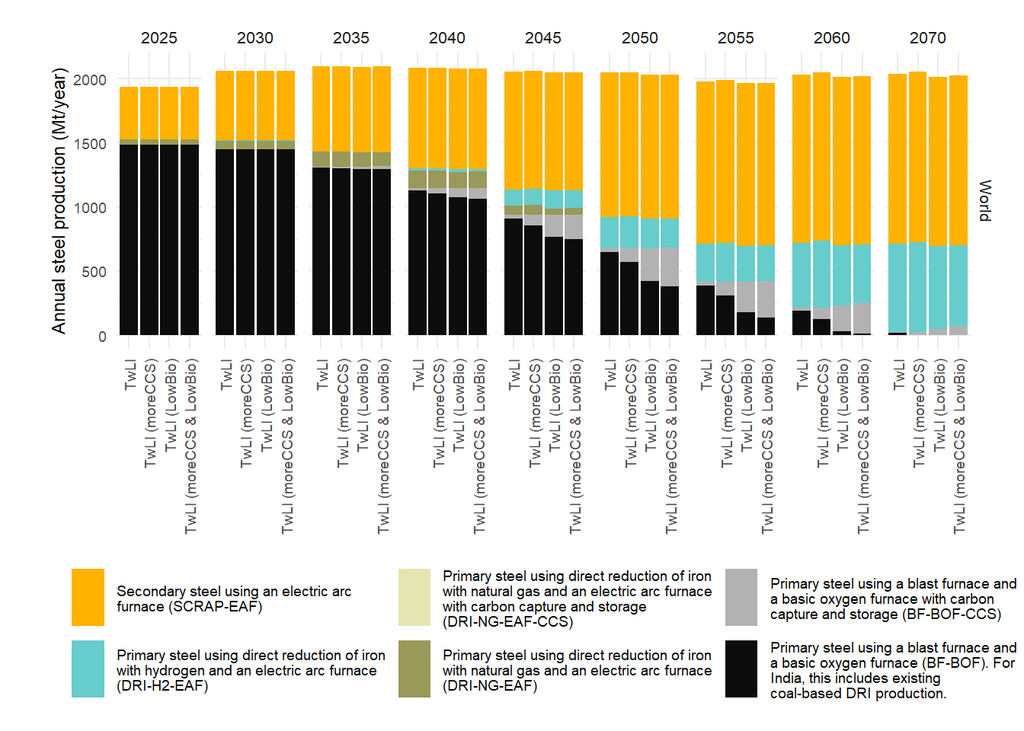

```r
scens_CCS <- list(scenario_TWLI, scenario_TWLI_highCCS, scenario_TWLI_lowBio, scenario_TWLI_lowBio_highCCS)
mif_list_CCS <- lapply(scens_CCS, function(scen) {
  mif <- read.quitte(scen$mif_file)
  mif
})

plot_REMIND_steel_production(mif_list_CCS, fig_name = "FigureS3")
```

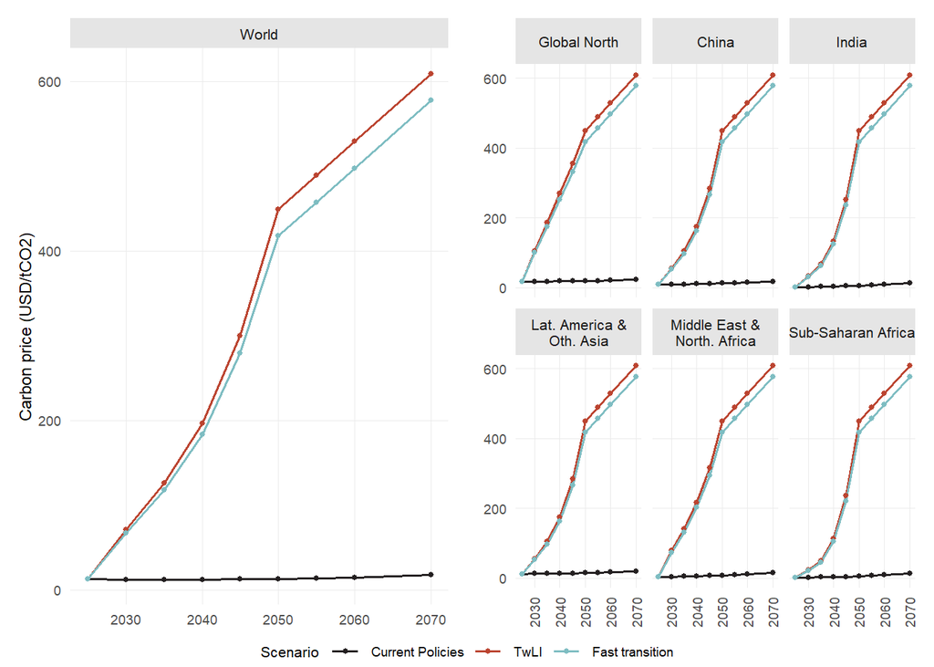

```r
## Supp. Fig 4: CO2 prices from all main scenarios

mif_list <- lapply(scenarios, function(scen) {
  mif <- read.quitte(scen$mif_file)
  mif
})

plot_co2_prices(mif_list, fig_name = "FigureS4")
```

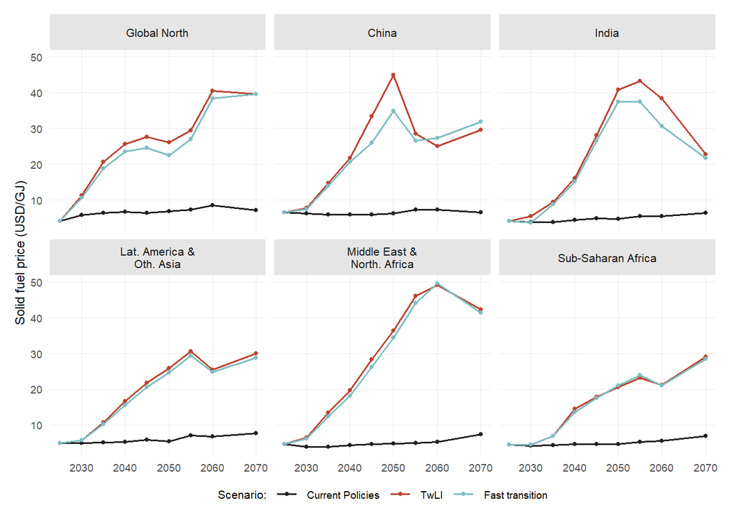

```r
plot_energy_prices(mif_list, "Price|Final Energy|Industry|Solids|Rawdata", "Solid fuel", fig_name = "FigureS5")
```

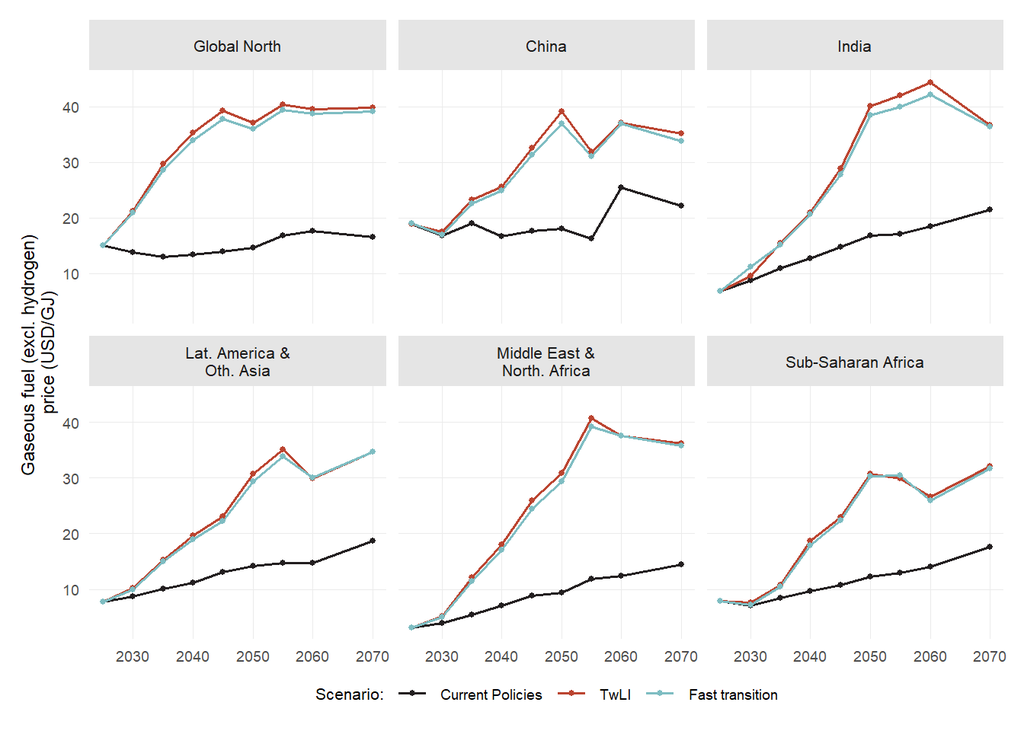

```r
plot_energy_prices(mif_list, "Price|Final Energy|Industry|Gases|Rawdata", "Gaseous fuel (excl. hydrogen)\n", fig_name = "FigureS6")
```

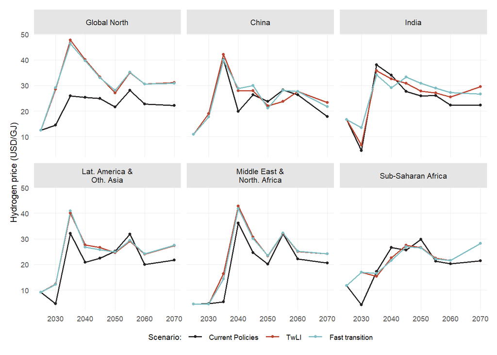

```r
plot_energy_prices(mif_list, "Price|Final Energy|Industry|Hydrogen|Rawdata", "Hydrogen", fig_name = "FigureS7")
```

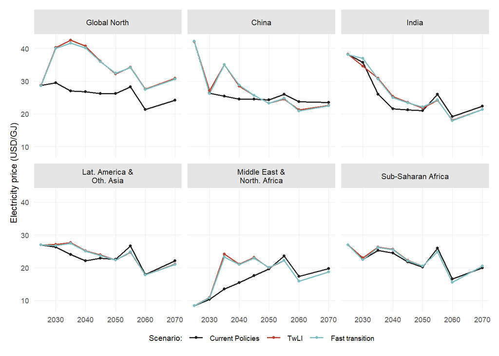

```r
plot_energy_prices(mif_list, "Price|Final Energy|Industry|Electricity|Rawdata", "Electricity", fig_name = "FigureS8")
```